# Analytics Programming Workflow

Nicholas Jojola

2026-03-07

## 1 Project Overview

##### 1.0.0.1 This project demonstrates an analytics workflow implemented in R for cleaning,summarizing, and analyzing financial data. The workflow includes:

##### 1.0.0.2 - Importing and validating CSV data

##### 1.0.0.3 - Removing duplicate records

##### 1.0.0.4 - Generating grouped summary statistics by business state

##### 1.0.0.5 - Detecting negative financial ratios

##### 1.0.0.6 - Creating a debt-to-income metric

##### 1.0.0.7 - Visualizing financial trends across states

##### 1.0.0.8 Algorithm documentation is provided through both a flowchart and pseudocode

##### 1.0.0.9 to clearly communicate the data processing logic.

## 2 Dataset Description

##### 2.0.0.1 The dataset contains financial metrics for businesses across multiple states,including revenue, equity, and debt variables. These metrics allow us to evaluate financial performance and calculate derived ratios such as debt-to-income.

##### 2.0.0.2 Key variables include:

##### 2.0.0.3 - `Business.State`

##### 2.0.0.4 - `Total.Revenue`

##### 2.0.0.5 - `Total.Equity`

##### 2.0.0.6 - `Total.Long.term.Debt`

##### 2.0.0.7 - `Debt.to.Equity`

##### 2.0.0.8 Flowchart

[interactive chart not shown]

## 3 Algorithm Pseudocode

1. Begin program
2. Import CSV data into dataframe `df`
3. Identify duplicate rows
4. Remove duplicate rows
5. Group data by business state
6. Calculate mean, median, min, and max for numeric columns
7. Identify rows where Debt-to-Equity < 0
8. Save those rows as `neg_df`
9. Create debt-to-income variable
10. Handle division-by-zero cases
11. Append new variable to dataset
12. Output final dataframe
13. End program

## 4 Flowchart and Pseudocode Logic

The following table summarizes the algorithm used in the data processing workflow.  
Each step corresponds to a component of the flowchart and explains the logical operations performed during the analysis.

| Flowchart Step | Pseudocode | Explanation |
| --- | --- | --- |
| **Begin** | Start program | Marks the beginning of the program execution. |
| **Read CSV and set as `df`** | Import comma-separated value data into a dataframe named `df`. | Establishes a structured container for data manipulation and analysis. |
| **Check for duplicate rows** | Identify duplicate rows in `df`. | Detects duplicate records that may distort statistical summaries or calculations. |
| **Duplicates detected?** | If duplicates exist → remove duplicate rows from `df`. | Ensures data integrity by preventing multiple instances of the same record. |
| **No duplicates detected** | Proceed to the next step. | If no duplicates exist, the dataset remains unchanged. |
| **Group data by state** | Group the dataframe by `Business.State`. | Organizes the data into groups so that summary statistics can be calculated by state. |
| **Calculate summary statistics** | For each numeric variable calculate mean, median, minimum, and maximum. | Produces descriptive statistics that summarize the financial characteristics of businesses within each state. |
| **Check for negative debt-to-equity values** | Filter rows where `Debt.to.Equity < 0`. | Identifies potentially problematic financial entries where the ratio is negative. |
| **Negative values detected?** | Save filtered rows to a new dataframe named `neg_df`. | Preserves anomalous values for inspection while allowing the main dataset to continue through the workflow. |
| **Continue processing** | Proceed with additional calculations and transformations. | The cleaned dataset is now prepared for feature engineering and visualization. |

##### 4.0.0.4 Concatenate d_2_I to df, set as final_df Concatenate d_2_I data frame to df The debt-to-income ratio is concatenated back into the original dataset for easy queries.

##### 4.0.0.5 Print final_df Output data from final_df data frame Print a readable dataframe with all pertinent calculations

##### 4.0.0.6 End Program

##### 4.0.0.7 The program’s logic follows a structured data processing pipeline designed to ensure accuracy, integrity, and analytical validity.

##### 4.0.0.8 1. Import CSV data into a data frame (df). This establishes a structured container for manipulation.

##### 4.0.0.9 2. Detect and remove duplicates in the df to ensure data integrity before calculations. This will prevent measures of central tendency and other calculations from being inaccurate later in the program.

##### 4.0.0.26 removes duplicate entries

##### 4.0.0.27 Grouped data and summarized

```
## # A tibble: 40 × 29
##    Business.State Business.ID_mean Business.ID_median Business.ID_min
##    <chr>                     <dbl>              <dbl>           <dbl>
##  1 Alabama             1599117013          1599117013       422282013
##  2 Arizona             9445082013          9445082013      9445082013
##  3 Arkansas            8411162013          8411162013      7982872013
##  4 California         10630533442.        10342997013      7192742013
##  5 Colorado            9966963263         10081767013      3194582013
##  6 Connecticut        11233162013         11233162013     11233162013
##  7 Delaware            6936917013          8686742013       197452013
##  8 Florida             7520922013          8670152013      3507372013
##  9 Hawaii             15456542013         15456542013     15456542013
## 10 Idaho              11811257013         11811257013     10382772013
## # ℹ 30 more rows
## # ℹ 25 more variables: Business.ID_max <dbl>, Total.Long.term.Debt_mean <dbl>,
## #   Total.Long.term.Debt_median <dbl>, Total.Long.term.Debt_min <dbl>,
## #   Total.Long.term.Debt_max <dbl>, Total.Equity_mean <dbl>,
## #   Total.Equity_median <dbl>, Total.Equity_min <dbl>, Total.Equity_max <dbl>,
## #   Debt.to.Equity_mean <dbl>, Debt.to.Equity_median <dbl>,
## #   Debt.to.Equity_min <dbl>, Debt.to.Equity_max <dbl>, …
```

##### 4.0.0.28 filtered debt to equity by negative

```
##   Business.ID Business.State Total.Long.term.Debt Total.Equity Debt.to.Equity
## 1   934562013           Ohio            263880000   -111297000    -2.37095339
## 2  8343652013     Washington             10603000    -13271658    -0.79892053
## 3  9323722013     California             21560000    -15691000    -1.37403607
## 4 10919832013           Utah              2010000     -3602481    -0.55794881
## 5 11245242013     California               556000     -2063203    -0.26948390
## 6 14535932013        Montana             16459000     -3842372    -4.28355193
## 7 14639722013       New York               187000    -13037879    -0.01434282
##   Total.Liabilities Total.Revenue Profit.Margin
## 1         592174000     719783000    0.32069665
## 2          16625000       8949401    0.44811949
## 3          30048000      37782000    0.50595522
## 4           6302000      17757388    0.73256202
## 5           3819000       1100539   -0.08492293
## 6          32720000      33073414    0.58244407
## 7          15900000       2389053    0.30097825
```

##### 4.0.0.29 Debt to Income creation

##### 4.0.0.30 Concatination of debt to income into the original df

```
##     debt.to.income Business.ID  Business.State Total.Long.term.Debt
## 1     1.235000e-01    41872013        Kentucky             16889000
## 2     1.826652e-01    76232013            Iowa              6252000
## 3     4.997449e-02   160992013           Texas             19200000
## 4     2.646644e-01   197452013        Delaware            117592000
## 5     3.626760e-02   241042013        Illinois              4408000
## 6     9.072892e-02   252122013   Massachusetts             24583000
## 7     2.954898e-01   293322013       Tennessee            101759000
## 8     1.647654e-01   303022013           Texas             79382000
## 9     5.426520e-03   308312013   Massachusetts               232000
## 10    3.719049e-02   334882013         Indiana              4946000
## 11    8.704230e-02   390202013        New York              6000000
## 12    3.869097e-02   422282013         Alabama              5314000
## 13    2.414116e-01   497282013        New York             34026000
## 14    2.073236e-01   696332013        New York             14800000
```

[output cut: 287 more lines]

##### 4.0.0.31 Visualization

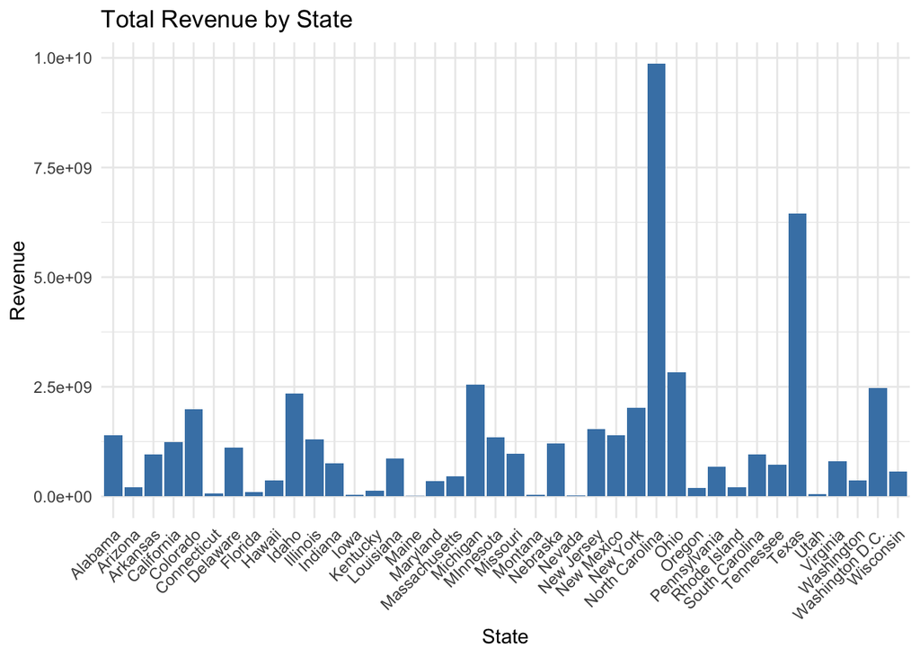

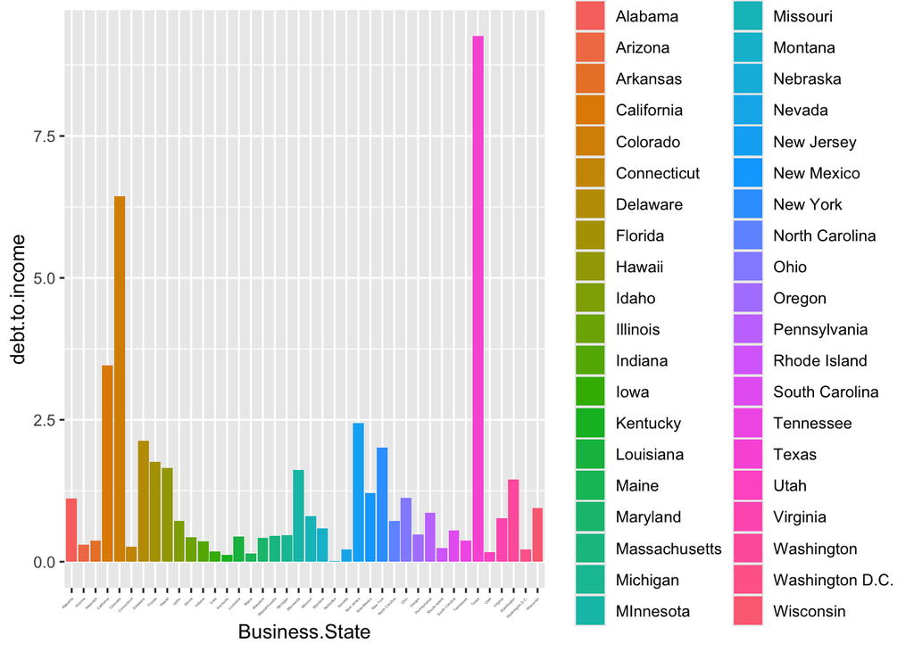

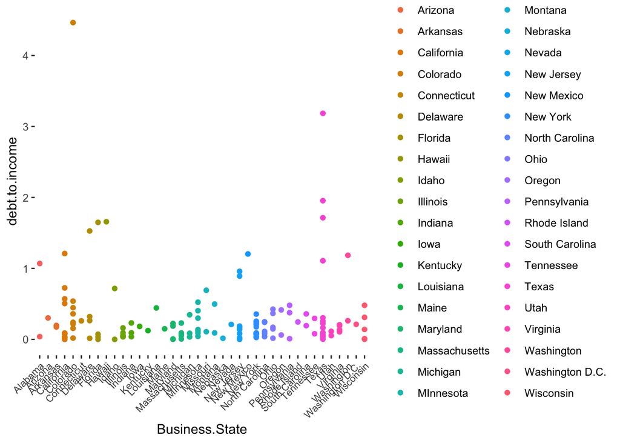

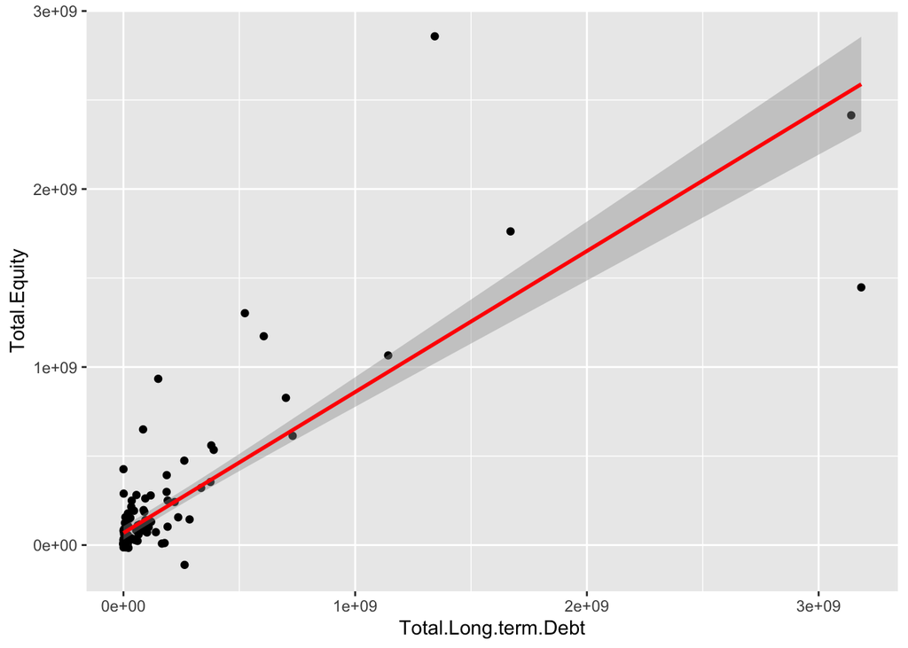

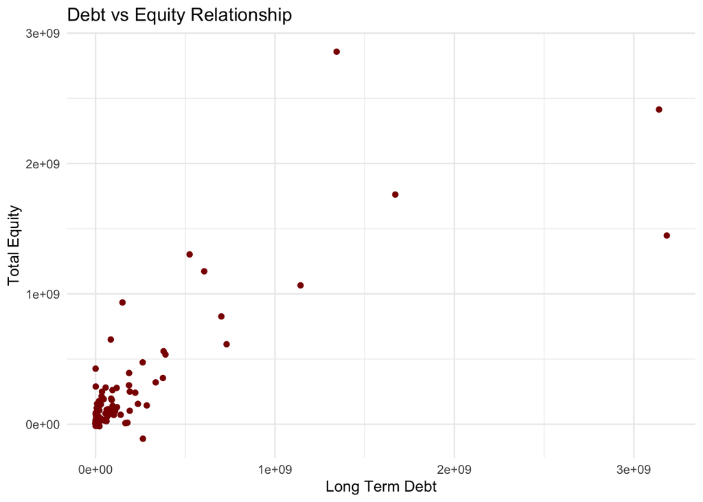

## 5 Conclusion

This project demonstrates a complete analytics pipeline in R, including data cleaning, transformation, feature engineering, and visualization.

The use of flowcharts and pseudocode provides clear documentation of the algorithmic workflow, ensuring that the analysis is both reproducible and understandable.

This approach reflects best practices in data analytics, where transparency and documentation are critical components of reliable data processing.